# Random Variable

Arnab Aich

## Definition and Example

- A **random variable** (RV) is a variable whose possible values are outcomes of a random experiment.
  - *Example*: Rolling a six-sided die.
    - The random variable (**X**) can take on values from 1 to 6.
  - *Example*: Rolling two six-sided die.
    - The random variable (**Y**) indicates sum of two face values (2 to 12).

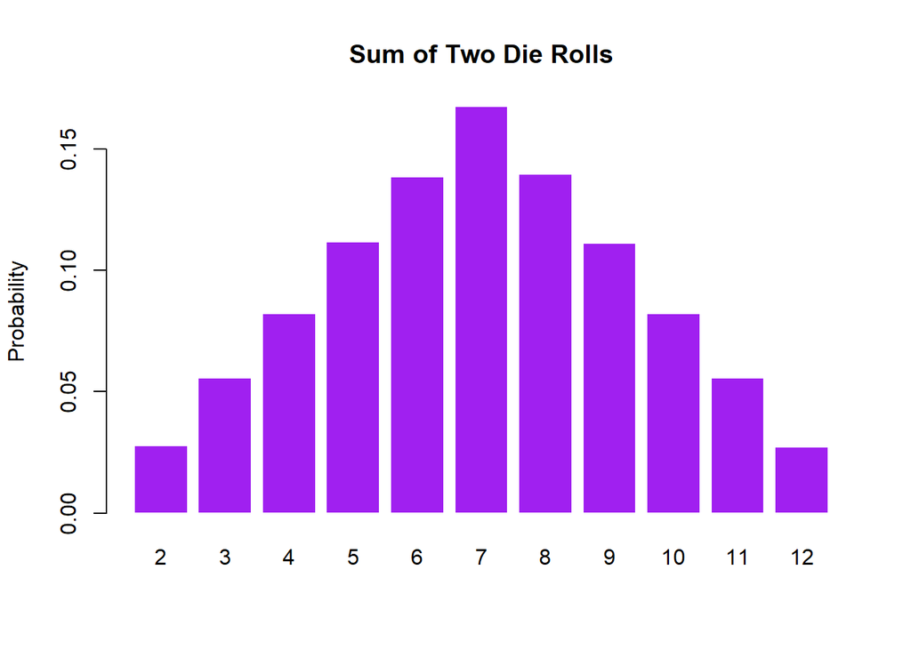

Probabilty Distribution of random variable $Y$ representing sum of two die rolls:

|  | 2 | 3 | 4 | 5 | 6 | 7 | 8 | 9 | 10 | 11 | 12 |
| --- | --- | --- | --- | --- | --- | --- | --- | --- | --- | --- | --- |
| $P(X=x)$ | 0.028 | 0.056 | 0.082 | 0.112 | 0.139 | 0.168 | 0.14 | 0.111 | 0.082 | 0.056 | 0.027 |

- Random variables can be:
  - **Discrete**: Can take on a countable number of values (e.g., die rolls).
  - **Continuous**: Can take on an infinite number of values within a range (e.g., IQ scores).

## Discrete Random Variable

- Suppose we roll a six-sided die $1000$ times and record the results. Let us consider $X$ be a random variable indicating the face value obtained on each roll.
  - We will now calculate probabilities and show the frequency and relative frequency tables.

| Face | Frequency | Rel_Freq |
| --- | --- | --- |
| 1 | 170 | 0.170 |
| 2 | 163 | 0.163 |
| 3 | 392 | 0.392 |
| 4 | 99 | 0.099 |
| 5 | 117 | 0.117 |
| 6 | 59 | 0.059 |

## Summary Statistics of a Discrete Random Variable

| Die Face (X) | $P(X = x)$ | $X * P(X = x)$ |
| --- | --- | --- |
| 1 | 0.15 | 0.15 |
| 2 | 0.15 | 0.30 |
| 3 | 0.35 | 1.05 |
| 4 | 0.10 | 0.40 |
| 5 | 0.10 | 0.50 |
| 6 | 0.05 | 0.30 |

- $E(X) = 0.15 + 0.30 + 1.05 + 0.40 + 0.50 + 0.30 = 2.70$
- **Variance** of a discrete random variable X is given by:
  - *$Var(X) = \Sigma [(x - E(X))^2 \cdot P(X = x)]$*
  - The calculation for the biased die example:

| Die Face (X) | $P(X = x)$ | $(X - E(X))^2$ | $(X - E(X))^2 P(X = x)$ |
| --- | --- | --- | --- |
| 1 | 0.15 | 2.89 | 0.43 |
| 2 | 0.15 | 0.49 | 0.07 |
| 3 | 0.35 | 0.09 | 0.03 |
| 4 | 0.10 | 1.69 | 0.17 |
| 5 | 0.10 | 5.29 | 0.53 |
| 6 | 0.05 | 10.89 | 0.54 |

- **$Var(X) = 0.43 + 0.07 + 0.03 + 0.17 + 0.53 + 0.54 = 1.77$**
- **Standard Deviation (SD)** is the square root of the variance:
  - **$SD(X) = \sqrt{Var(X)} = \sqrt{1.77} = 1.33$**

## Continuous Random Variable (Area Under Curve)

Let’s consider a continuous random variable representing **heights of adult males** in a given population. We have collected heights of $1000$ individuals. We sort them in a frequency table and draw a histogram. A **Density curve** can be obtained by joining the middle point of each bin.

We are interested in calculating the following probabilities using this hypothetical data:

**P(height < 165 cm)**: The probability of selecting an individual shorter than 165 cm.

**P(height > 185 cm)**: The probability of selecting an individual taller than 185 cm.

**P(165 cm ≤ height ≤ 185 cm)**: The probability of selecting an individual whose height falls between 165 cm and 185 cm. These probabilities can be idenfied using the area under the density curve.

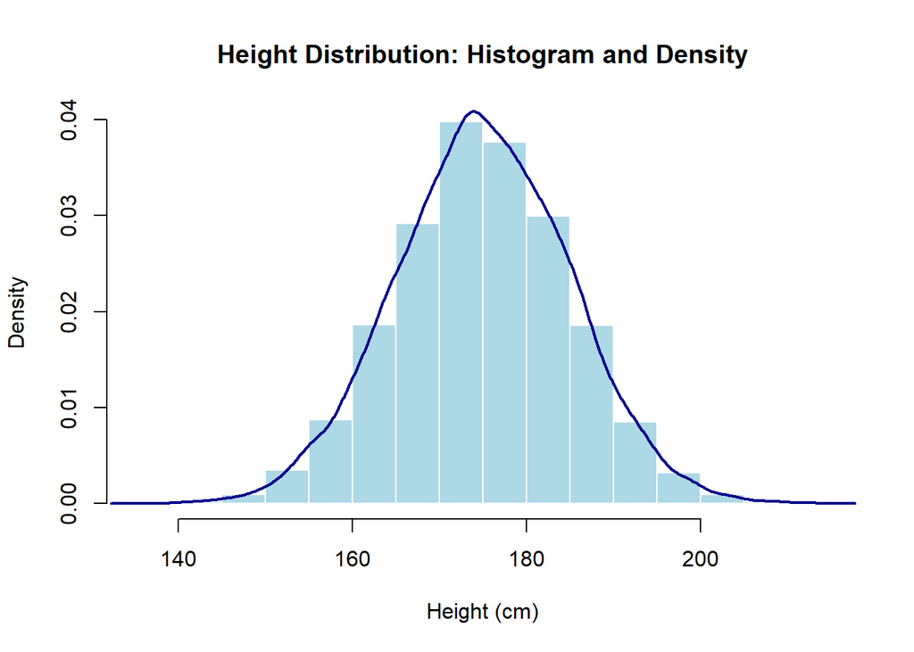

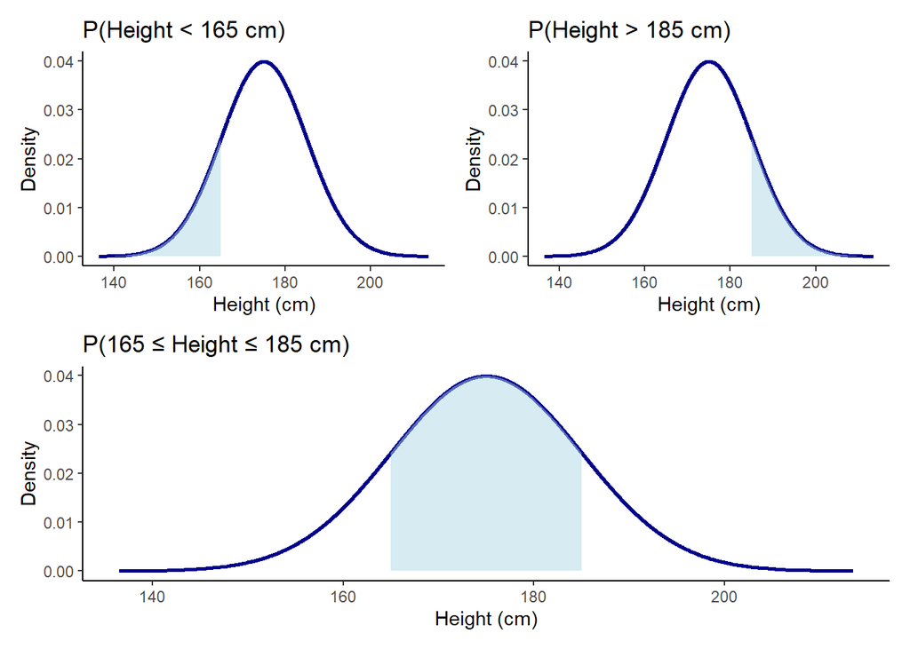

## Question and Answer

#### **What is a random variable?**

- A random variable is a variable that takes on different values based on the outcome of a random experiment.

#### **What is the difference between discrete and continuous random variables?**

- Discrete random variables can take on countable values, while continuous random variables can take on any value within a range.

#### **How do we calculate the expected value of a discrete random variable?**

- The expected value (mean) is calculated as $E(X) = \sum x \cdot P(X = x)$.

#### **What is the purpose of calculating variance and standard deviation?**

- Variance and standard deviation tell us how much the values of a random variable are spread out from the mean.

#### **How is the probability calculated for a continuous random variable?**

- The probability for a continuous random variable is calculated by finding the area under the probability density function (PDF) for a given range.